# Coursera ML Final Project

Mohammad Tantawy

November 19, 2018

## Coursera Practical Machine Learning - Final Project

One thing that people regularly do is quantify how much of a particular activity they do, but they rarely quantify how well they do it. In this project, the goal will be to use data from accelerometers on the belt, forearm, arm, and dumbell of 6 participants to build model which can predict if the activity is done in correct way.

### Loading and EDA

following some EDA results after loading the training data  
Data Dimenssion

```r
library(ggplot2)
TData <- read.csv("pml-training.csv")
DDim <- as.character(dim(TData))
DataDim <- paste("Training Data Dim = ", DDim[1] , " X ",  DDim[2])
print(DataDim)
```

```
## [1] "Training Data Dim =  19622  X  160"
```

Sample of 8 random columns

```r
print(head(n= 4, TData[,sample(160,8)]))
```

```
##   gyros_belt_x accel_dumbbell_y num_window stddev_pitch_belt avg_yaw_arm
## 1         0.00               47         11                NA          NA
## 2         0.02               47         11                NA          NA
## 3         0.00               46         11                NA          NA
## 4         0.02               48         12                NA          NA
##   total_accel_forearm magnet_belt_y skewness_pitch_arm
## 1                  36           599
## 2                  36           608
## 3                  36           600
## 4                  36           604
```

Following Scatter plot for some features against classe

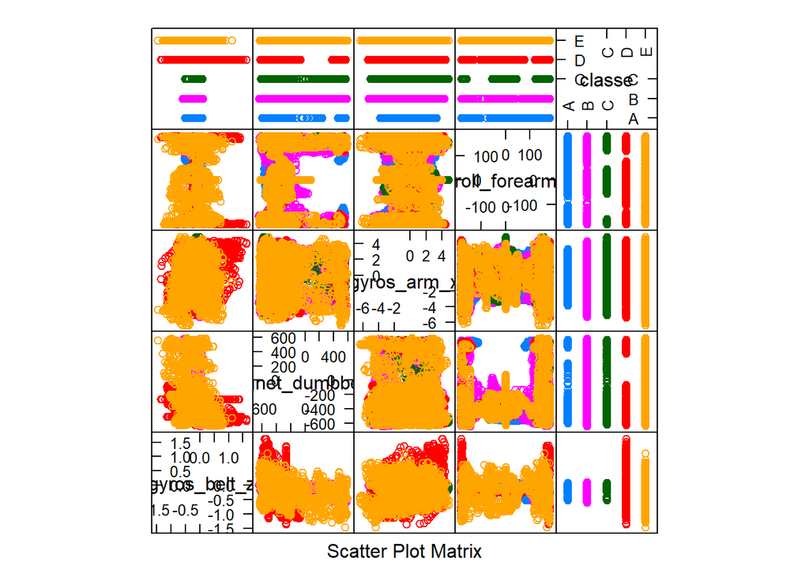

```r
featurePlot(x = TData[,c("gyros_belt_z","magnet_dumbbell_x","gyros_arm_x","roll_forearm", "classe")], y = TData$classe, plot = "pairs")
```

### choose features set

Features used to train the model, had been selected based on filter method of CFS(Correlation-based Feature Selection) of Mark.A Hall university of Waikato, Hamilton New Zealand.  
as this is methodology does not depend on the used learning algorithm (during training model) and it could be applied to a large number of features as preprocessing step.  
refer to https://researchcommons.waikato.ac.nz/bitstream/handle/10289/1024/uow-cs-wp-2000-08.pdf  
*this filter method is implemented in library “FSelector”*  
**following code used to select the features**

```r
library(FSelector)
TData <- read.csv("pml-training.csv")
colToSelectFrom = c(c(15:159),160)
SmlTData = TData[,colToSelectFrom]
Fselected <- cfs(classe~., SmlTData)
print(Fselected)
```

```
##  [1] "gyros_belt_z"      "accel_belt_z"      "magnet_belt_z"
##  [4] "gyros_arm_x"       "magnet_arm_x"      "gyros_dumbbell_y"
##  [7] "magnet_dumbbell_x" "magnet_dumbbell_y" "magnet_dumbbell_z"
## [10] "roll_forearm"      "pitch_forearm"
```

### The Criteria to select a model

**1-** First use the selected features to train three models which expected to have good results as classifiers.

```r
SelFeatures <- c("gyros_belt_z","accel_belt_z","magnet_belt_z","gyros_arm_x","magnet_arm_x","gyros_dumbbell_y","magnet_dumbbell_x","magnet_dumbbell_y","magnet_dumbbell_z","roll_forearm","pitch_forearm","classe")
```

**2-** The three models are Random Forest-RF, Boosting-BGM and Support Vector Machine-SVM.  
**3-** Using fold k=3 to divide the data into 2/3 training data and 1/3 for testing data.  
**4-** Training and testing data will be selected in random order, to make sure it covers all possible values of “classe” in both sets.  
**5-** Repeat the previous step 3 times to have 3 different partitioning samples  
**following code of partitioning the data into three samples**

```r
set.seed(3322)
DtLeng <- length(TData$classe)
#create three indeices for three partioned data
ind1 = sample(DtLeng, as.integer(DtLeng/3))
ind2 = sample(DtLeng, as.integer(DtLeng/3))
ind3 = sample(DtLeng, as.integer(DtLeng/3))

TDPart1 <- TData[-ind1,SelFeatures] #2/3 of the data for training
TstPart1 <- TData[ind1,SelFeatures] #1/3 of the data for testing

TDPart2 <- TData[-ind2,SelFeatures] #second partition of data
TstPart2 <- TData[ind2,SelFeatures]

TDPart3 <- TData[-ind3,SelFeatures] #third partition of data
TstPart3 <- TData[ind3,SelFeatures]
```

**6-** For each model, train the model with training data and test its accuracy with test data for each of the three samples of data.  
**7-** Get the accuracy of the three testing results for each model by getting the percentage of the correct classification.  
**8-** Model with the highest average results will be selected.  
**following sample of training and testing for the first sample of the data**

```r
library(caret)
library(e1071)

modelRF1 <- train(classe ~ ., method="rf",data=TDPart1)
resRF1 <- predict(modelRF1, newdata = TstPart1)
accuracyRF1 <- length(resRF1[resRF1 == TstPart1$classe])/ length(TstPart1$classe)

modelGBM1 <- <- train(classe ~ ., method="gbm",data=TDPart1, verbose = FALSE)
resGBM1 <- predict(modelGBM1, newdata = TstPart1)
accuracyresGBM1 <- length(resGBM1[resGBM1 == TstPart1$classe])/ length(TstPart1$classe)

modelSVM1 <- svm(classe ~ ., data=TDPart1)
resSVM1 <- predict(modelSVM1, newdata = TstPart1)
accuracySVM1 <- length(resSVM1[resSVM1 == TstPart1$classe])/ length(TstPart1$classe)
```

### following results accuracy of each model with each sample of data

|  | Sample1 | Sample2 | Sample3 |
| --- | --- | --- | --- |
| RF | 0.9735474 | 0.9723242 | 0.9730887 |
| GBM | 0.8839450 | 0.8785933 | 0.8854740 |
| SVM | 0.8527523 | 0.8467890 | 0.8522936 |

**it is Clear that best accuracy for RF model.**

so the selected model is:  
**-RF with features: “gyros_belt_z”, “accel_belt_z”, “magnet_belt_z”, “gyros_arm_x”, “magnet_arm_x”, “gyros_dumbbell_y”, “magnet_dumbbell_x”, “magnet_dumbbell_y”, “magnet_dumbbell_z”, “roll_forearm”, and “pitch_forearm”**  
**-Expected out of sample error to be max 3%**

By training the model with the full training data, and then predict the project quiz **results accuracy is 100%. for all 20 cases**

**End of Report**